# R Notebook

1. Set working directory

```r
setwd("~/Library/CloudStorage/OneDrive-UniversityofEdinburgh/4th year/dissertation/dissertation")
```

2. Load packages

```r
library(skimr)  #summary
library(tidyverse)
library(lubridate)  #dates management
library(gridExtra)  #arrange plots
```

2.2. Creates functions

- Function for graph asthetics

```r
theme_graphs_env_cond <- function(){
  theme_classic() +
  theme(axis.text.x = element_text(angle = 90))+
   theme(axis.text = element_text(size = 11),  # Adjust the size as needed
          axis.title = element_text(size = 18),
        legend.text = element_text(size=14))
  }
```

3. Load the data and see its structure

```r
data <- read.csv("Data_PAM_Scott_Base.csv") # load data
skimr::skim(data)  # see a summary of the whole data
```

```
── Data Summary ────────────────────────
                           Values
Name                       data
Number of rows             26722
Number of columns          43
_______________________
Column type frequency:
  character                9
  numeric                  34
________________________
Group variables            None
```

|  | skim_variable | n_missing | complete_rate | min | max | empty | n_unique | whitespace |
| --- | --- | --- | --- | --- | --- | --- | --- | --- |
| 1 | Datetime | 0 | 1 | 16 | 20 | 0 | 26719 | 0 |
| 2 | Date | 0 | 1 | 5 | 10 | 0 | 1115 | 0 |
| 3 | Time | 0 | 1 | 6 | 8 | 0 | 118 | 0 |
| 4 | X | 0 | 1 | 5 | 7 | 0 | 956 | 0 |
| 5 | X3.F | 0 | 1 | 1 | 3 | 0 | 277 | 0 |
| 6 | X3.Fm. | 0 | 1 | 1 | 3 | 0 | 373 | 0 |
| 7 | X3.PAR | 0 | 1 | 1 | 4 | 0 | 730 | 0 |
| 8 | X3.Temp | 0 | 1 | 1 | 5 | 0 | 190 | 0 |
| 9 | diff.2 | 0 | 1 | 1 | 7 | 0 | 205 | 0 |

|  | skim_variable | n_missing | complete_rate | mean | sd | p0 | p25 | p50 | p75 | p100 | hist |
| --- | --- | --- | --- | --- | --- | --- | --- | --- | --- | --- | --- |
| 1 | Time..abs.ms. | 0 | 1.0000000 | 1.595785e+12 | 2.776981e+10 | 1.547695e+12 | 1.571743e+12 | 1.595790e+12 | 1.619851e+12 | 1.643900e+12 | ▇▇▇▇▇ |
| 2 | Time..rel.ms. | 0 | 1.0000000 | 1.742582e+10 | 1.001917e+10 | 1.544100e+07 | 8.373028e+09 | 1.900467e+10 | 2.647776e+10 | 3.291746e+10 | ▆▅▆▇▇ |
| 3 | JD.nz | 0 | 1.0000000 | 1.816921e+02 | 1.064690e+02 | 1.506000e+00 | 8.845675e+01 | 1.812715e+02 | 2.740453e+02 | 3.674950e+02 | ▇▇▇▇▇ |
| 4 | JD.running.nz | 0 | 1.0000000 | 5.740953e+02 | 3.211254e+02 | 1.767900e+01 | 2.960585e+02 | 5.743910e+02 | 8.518598e+02 | 1.131204e+03 | ▇▇▇▇▇ |
| 5 | Year.percent.nz | 0 | 1.0000000 | 1.568566e+02 | 8.773920e+01 | 4.830300e+00 | 8.089025e+01 | 1.569375e+02 | 2.327486e+02 | 3.090720e+02 | ▇▇▇▇▇ |
| 6 | Dec.Year.nz | 0 | 1.0000000 | 2.056857e+01 | 8.773919e-01 | 1.904830e+01 | 1.980893e+01 | 2.056935e+01 | 2.132747e+01 | 2.209100e+01 | ▇▇▇▇▇ |
| 7 | Julian.Day.UTC | 0 | 1.0000000 | 1.811921e+02 | 1.064690e+02 | 1.006000e+00 | 8.795675e+01 | 1.807715e+02 | 2.735453e+02 | 3.669950e+02 | ▇▇▇▇▇ |
| 8 | JD.running.UTC | 0 | 1.0000000 | 5.735953e+02 | 3.211254e+02 | 1.717900e+01 | 2.955585e+02 | 5.738910e+02 | 8.513598e+02 | 1.130704e+03 | ▇▇▇▇▇ |
| 9 | Year.percent.UTC | 0 | 1.0000000 | 1.567200e+02 | 8.773920e+01 | 4.694000e+00 | 8.075375e+01 | 1.568010e+02 | 2.326120e+02 | 3.089350e+02 | ▇▇▇▇▇ |
| 10 | UTC | 0 | 1.0000000 | 2.056720e+01 | 8.773920e-01 | 1.904690e+01 | 1.980752e+01 | 2.056805e+01 | 2.132608e+01 | 2.208940e+01 | ▇▇▇▇▇ |

[output cut: 24 more lines]

```r
str(data)  # see the structure of each variable
```

```
'data.frame':   26722 obs. of  43 variables:
 $ Datetime        : chr  "17/01/2019 04:17" "17/01/2019 05:17" "17/01/2019 06:17" "17/01/2019 07:17" ...
 $ Time..abs.ms.   : num  1.55e+12 1.55e+12 1.55e+12 1.55e+12 1.55e+12 ...
 $ Time..rel.ms.   : num  15441000 19041000 22641000 26241000 29841000 ...
 $ JD.nz           : num  17.7 17.7 17.8 17.8 17.8 ...
 $ JD.running.nz   : num  17.7 17.7 17.8 17.8 17.8 ...
 $ Year.percent.nz : num  4.83 4.84 4.85 4.86 4.88 ...
 $ Dec.Year.nz     : num  19 19 19 19 19 ...
 $ Date            : chr  "43482" "43482" "43482" "43482" ...
 $ Time            : chr  "0.1787" "0.2204" "0.2620" "0.3037" ...
 $ Julian.Day.UTC  : num  17.2 17.2 17.3 17.3 17.3 ...
 $ JD.running.UTC  : num  17.2 17.2 17.3 17.3 17.3 ...
 $ Year.percent.UTC: num  4.69 4.71 4.72 4.73 4.74 ...
 $ UTC             : num  19 19 19 19 19 ...
 $ No.             : int  1 2 3 4 5 6 7 8 9 10 ...
```

[output cut: 29 more lines]

```r
tail(data)  # view the last 6 rows of data
```

|  | Datetime | Time..abs.ms. | Time..rel.ms. | JD.nz | JD.running.nz | Year.percent.nz | Dec.Year.nz | Date | Time | Julian.Day.UTC | JD.running.UTC | Year.percent.UTC | UTC | No. | X1.F | X1.Fm. | X1.PAR | X1.Temp | X1.Y..II. | diff | X | X1.ETR | X2.F | X2.Fm. | X2.PAR | X2.Temp | X2.Y..II. | diff.1 | X2.ETR | … |
| --- | --- | --- | --- | --- | --- | --- | --- | --- | --- | --- | --- | --- | --- | --- | --- | --- | --- | --- | --- | --- | --- | --- | --- | --- | --- | --- | --- | --- | --- | --- |
| 26717 | 03/02/2022 11:53 | 1.64389e+12 | 2545200000 | 34.995 | 1130.995 | 309.015 | 22.090 | 03/02/2022 | 11:53:13 | 34.495 | 1130.495 | 308.878 | 22.0888 | 26717 | 27 | 29 | 260 | 2.3 | 0 | 2 | 0.069 | 0 | 21 | 26 | 94 | 2.5 | 0 | 5 | 0 | … |
| 26718 | 03/02/2022 12:53 | 1.64389e+12 | 2548800000 | 35.037 | 1131.037 | 309.026 | 22.090 | 03/02/2022 | 12:53:13 | 34.537 | 1130.537 | 308.890 | 22.0889 | 26718 | 29 | 29 | 184 | 0.8 | 0 | 0 | 0.000 | 0 | 24 | 24 | 100 | 1.5 | 0 | 0 | 0 | … |
| 26719 | 03/02/2022 13:53 | 1.64389e+12 | 2552400000 | 35.079 | 1131.079 | 309.038 | 22.090 | 03/02/2022 | 13:53:13 | 34.579 | 1130.579 | 308.901 | 22.0890 | 26719 | 27 | 29 | 101 | -1.4 | 0 | 2 | 0.069 | 0 | 22 | 26 | 152 | -0.2 | 0 | 4 | 0 | … |
| 26720 | 03/02/2022 14:53 | 1.64390e+12 | 2556000000 | 35.120 | 1131.120 | 309.049 | 22.090 | 03/02/2022 | 14:53:13 | 34.620 | 1130.620 | 308.913 | 22.0891 | 26720 | 28 | 30 | 318 | -3.2 | 0 | 2 | 0.067 | 0 | 23 | 27 | 264 | -0.7 | 0 | 4 | 0 | … |
| 26721 | 03/02/2022 15:53 | 1.64390e+12 | 2559600000 | 35.162 | 1131.162 | 309.061 | 22.091 | 03/02/2022 | 15:53:13 | 34.662 | 1130.662 | 308.924 | 22.0892 | 26721 | 26 | 30 | 288 | -1.2 | 0 | 4 | 0.133 | 0 | 24 | 27 | 328 | -0.4 | 0 | 3 | 0 | … |
| 26722 | 03/02/2022 16:53 | 1.64390e+12 | 2563200000 | 35.204 | 1131.204 | 309.072 | 22.091 | 03/02/2022 | 16:53:13 | 34.704 | 1130.704 | 308.935 | 22.0894 | 26722 | 27 | 28 | 127 | -2.2 | 0 | 1 | 0.036 | 0 | 23 | 24 | 452 | -1.4 | 0 | 1 | 0 | … |

```r
head(data)  # view the first 6 rows of data
```

|  | Datetime | Time..abs.ms. | Time..rel.ms. | JD.nz | JD.running.nz | Year.percent.nz | Dec.Year.nz | Date | Time | Julian.Day.UTC | JD.running.UTC | Year.percent.UTC | UTC | No. | X1.F | X1.Fm. | X1.PAR | X1.Temp | X1.Y..II. | diff | X | X1.ETR | X2.F | X2.Fm. | X2.PAR | X2.Temp | X2.Y..II. | diff.1 | X2.ETR | … |
| --- | --- | --- | --- | --- | --- | --- | --- | --- | --- | --- | --- | --- | --- | --- | --- | --- | --- | --- | --- | --- | --- | --- | --- | --- | --- | --- | --- | --- | --- | --- |
| 1 | 17/01/2019 04:17 | 1.547695e+12 | 15441000 | 17.679 | 17.679 | 4.8303 | 19.0483 | 43482 | 0.1787 | 17.179 | 17.179 | 4.694 | 19.0469 | 1 | 106 | 172 | 543 | 2.3 | 0.384 | 66 | 0.384 | 87.4 | 133 | 179 | 994 | 2.0 | 0.257 | 46 | 107.0 | … |
| 2 | 17/01/2019 05:17 | 1.547699e+12 | 19041000 | 17.720 | 17.720 | 4.8416 | 19.0484 | 43482 | 0.2204 | 17.220 | 17.220 | 4.705 | 19.0471 | 2 | 120 | 203 | 557 | 1.0 | 0.409 | 83 | 0.409 | 95.5 | 114 | 163 | 971 | 2.0 | 0.301 | 49 | 122.5 | … |
| 3 | 17/01/2019 06:17 | 1.547702e+12 | 22641000 | 17.762 | 17.762 | 4.8530 | 19.0485 | 43482 | 0.2620 | 17.262 | 17.262 | 4.716 | 19.0472 | 3 | 127 | 234 | 623 | -0.9 | 0.457 | 107 | 0.457 | 119.3 | 157 | 268 | 712 | 1.0 | 0.414 | 111 | 123.5 | … |
| 4 | 17/01/2019 07:17 | 1.547706e+12 | 26241000 | 17.804 | 17.804 | 4.8644 | 19.0486 | 43482 | 0.3037 | 17.304 | 17.304 | 4.728 | 19.0473 | 4 | 119 | 210 | 692 | -0.9 | 0.433 | 91 | 0.433 | 125.6 | 138 | 217 | 534 | -0.2 | 0.364 | 79 | 81.4 | … |
| 5 | 17/01/2019 08:17 | 1.547709e+12 | 29841000 | 17.845 | 17.845 | 4.8758 | 19.0488 | 43482 | 0.3454 | 17.345 | 17.345 | 4.739 | 19.0474 | 5 | 79 | 103 | 1335 | -0.2 | 0.233 | 24 | 0.233 | 130.3 | 132 | 200 | 774 | 1.3 | 0.340 | 68 | 110.3 | … |
| 6 | 17/01/2019 09:17 | 1.547713e+12 | 33441000 | 17.887 | 17.887 | 4.8872 | 19.0489 | 43482 | 0.3870 | 17.387 | 17.387 | 4.751 | 19.0475 | 6 | 118 | 202 | 352 | -1.7 | 0.416 | 84 | 0.416 | 61.4 | 143 | 235 | 330 | -0.7 | 0.391 | 92 | 54.1 | … |

Data of sensors 1,2 and 4 are for the moss and 3 is for the lichen. Data is from Jan 2019 to Feb 2022. I am going to consider summer form 1 Nov to 15 Feb. I currently have data for 3 summers: 2019-2020, 2020-2021, 2021-2022.

## 4. Format data in a way that is going to be useful to me

4.1. Remove weird times and dates and divide the useful ones

```r
data_clean <- data[, -c(2:13)] %>%   # create a new data set without columns 2 to 13
  mutate(Day_cum = as.numeric(data$Date)) # maintain cumulative date but change column name to more informative one and make it numeric
data_clean <- data_clean %>%
  mutate(Date = parse_date_time(Datetime, 'dmy HM'))   # indicate the format the date is wanted
print(data_clean[is.na(data_clean$Date), ])  # Check for rows with parsing issues\
```

|  | Datetime | No. | X1.F | X1.Fm. | X1.PAR | X1.Temp | X1.Y..II. | diff | X | X1.ETR | X2.F | X2.Fm. | X2.PAR | X2.Temp | X2.Y..II. | diff.1 | X2.ETR | X3.F | X3.Fm. | X3.PAR | X3.Temp | X3.Y..II. | diff.2 | X3.ETR | X4.F | X4.Fm. | X4.PAR | X4.Temp | X4.Y..II. | … |
| --- | --- | --- | --- | --- | --- | --- | --- | --- | --- | --- | --- | --- | --- | --- | --- | --- | --- | --- | --- | --- | --- | --- | --- | --- | --- | --- | --- | --- | --- | --- |
| 584 | 00/01/1900 00:00:00 | 584 | 84 | 88 | 0 | -4.9 | 0 | 4 | 0.045 | 0 | 5 | 8 | 75 | -4.7 | 0 | 3 | 0 | 62 | 67 | 2 | -6.7 | 0 | 5 | 0 | 48 | 52 | 50 | -5.4 | 0 | … |

```r
#  Row 584 is problematic

data_clean[584, 1]<-"10/02/2019 10:08"  # Change the value to the correct one

data_clean <- data_clean %>%
  mutate(Date = parse_date_time(Datetime, 'dmy HM'))   # repeat with all the lines working

data_clean <- data_clean %>%  # create new columns with month, year,
  mutate(Month = month(Date), # day, minute
         Year = year(Date),
         Day = day(Date),
         Hour = hour(Date),
         Minute = minute(Date))

data_clean[584,]  # check it worked
```

|  | Datetime | No. | X1.F | X1.Fm. | X1.PAR | X1.Temp | X1.Y..II. | diff | X | X1.ETR | X2.F | X2.Fm. | X2.PAR | X2.Temp | X2.Y..II. | diff.1 | X2.ETR | X3.F | X3.Fm. | X3.PAR | X3.Temp | X3.Y..II. | diff.2 | X3.ETR | X4.F | X4.Fm. | X4.PAR | X4.Temp | X4.Y..II. | … |
| --- | --- | --- | --- | --- | --- | --- | --- | --- | --- | --- | --- | --- | --- | --- | --- | --- | --- | --- | --- | --- | --- | --- | --- | --- | --- | --- | --- | --- | --- | --- |
| 584 | 10/02/2019 10:08 | 584 | 84 | 88 | 0 | -4.9 | 0 | 4 | 0.045 | 0 | 5 | 8 | 75 | -4.7 | 0 | 3 | 0 | 62 | 67 | 2 | -6.7 | 0 | 5 | 0 | 48 | 52 | 50 | -5.4 | 0 | … |

```r
NA
```

4.2. Check the new data

```r
str(data_clean)
skimr::skim(data_clean)
```

|  | skim_variable | n_missing | complete_rate | min | max | empty | n_unique | whitespace |
| --- | --- | --- | --- | --- | --- | --- | --- | --- |
| 1 | Datetime | 0 | 1 | 16 | 16 | 0 | 26719 | 0 |
| 2 | X | 0 | 1 | 5 | 7 | 0 | 956 | 0 |
| 3 | X3.F | 0 | 1 | 1 | 3 | 0 | 277 | 0 |
| 4 | X3.Fm. | 0 | 1 | 1 | 3 | 0 | 373 | 0 |
| 5 | X3.PAR | 0 | 1 | 1 | 4 | 0 | 730 | 0 |
| 6 | X3.Temp | 0 | 1 | 1 | 5 | 0 | 190 | 0 |
| 7 | diff.2 | 0 | 1 | 1 | 7 | 0 | 205 | 0 |

|  | skim_variable | n_missing | complete_rate | mean | sd | p0 | p25 | p50 | p75 | p100 | hist |
| --- | --- | --- | --- | --- | --- | --- | --- | --- | --- | --- | --- |
| 1 | No. | 0 | 1.0000000 | 1.336150e+04 | 7.714121e+03 | 1.0 | 6681.25 | 13361.5 | 20041.75 | 26722.000 | ▇▇▇▇▇ |
| 2 | X1.F | 0 | 1.0000000 | 7.699214e+01 | 6.373717e+01 | 18.0 | 43.00 | 64.0 | 69.00 | 594.000 | ▇▁▁▁▁ |
| 3 | X1.Fm. | 0 | 1.0000000 | 9.471873e+01 | 1.091555e+02 | 21.0 | 46.00 | 67.0 | 72.00 | 898.000 | ▇▁▁▁▁ |
| 4 | X1.PAR | 0 | 1.0000000 | 5.950457e+01 | 1.688519e+02 | 0.0 | 0.00 | 0.0 | 0.00 | 1335.000 | ▇▁▁▁▁ |
| 5 | X1.Temp | 0 | 1.0000000 | -1.471405e+01 | 8.915401e+00 | -27.9 | -21.40 | -18.2 | -9.20 | 15.000 | ▇▆▂▂▁ |
| 6 | X1.Y..II. | 0 | 1.0000000 | 4.603596e-02 | 1.189491e-01 | 0.0 | 0.00 | 0.0 | 0.00 | 0.532 | ▇▁▁▁▁ |
| 7 | diff | 1 | 0.9999626 | 1.772707e+01 | 4.792729e+01 | -4.0 | 2.00 | 3.0 | 5.00 | 478.000 | ▇▁▁▁▁ |
| 8 | X1.ETR | 0 | 1.0000000 | 7.007249e+00 | 2.268370e+01 | 0.0 | 0.00 | 0.0 | 0.00 | 206.600 | ▇▁▁▁▁ |
| 9 | X2.F | 0 | 1.0000000 | 2.273744e+01 | 4.992338e+01 | 0.0 | 3.00 | 5.0 | 8.00 | 436.000 | ▇▁▁▁▁ |
| 10 | X2.Fm. | 0 | 1.0000000 | 4.277838e+01 | 1.055464e+02 | 1.0 | 6.00 | 8.0 | 11.00 | 1207.000 | ▇▁▁▁▁ |

[output cut: 20 more lines]

|  | skim_variable | n_missing | complete_rate | min | max | median | n_unique |
| --- | --- | --- | --- | --- | --- | --- | --- |
| 1 | Date | 0 | 1 | 2019-01-17 04:17:00 | 2022-02-03 16:53:00 | 2020-07-26 21:23:00 | 26719 |

4.3. Change the diff columns names to match the rest of columns

```r
data_clean<-data_clean %>%
  rename(X1.diff = diff,
         X2.diff = diff.1,
         X3.diff = diff.2,
         X4.diff = diff.3)
```

4.4. Need to change some variables of format

```r
data_clean <- data_clean %>%
  mutate(X1.PAR = as.numeric(X1.PAR),  # Change PAR of X1, X2 and X3 to numeric
         X2.PAR = as.numeric(X2.PAR),
         X3.PAR = as.numeric(X3.PAR),
         X4.PAR = as.numeric(X4.PAR),
         X3.F = as.numeric(X3.F),  # Change F and Fm to numeric
         X3.Fm. = as.numeric(X3.Fm.),
         X3.Temp = as.numeric(X3.Temp),  # Change Temp 3 to numeric
         X1.diff = as.numeric(X1.diff),  # Change all diff to numeric
         X2.diff = as.numeric(X2.diff),
         X3.diff = as.numeric(X3.diff),
         X4.diff = as.numeric(X4.diff))
         #Month = as.factor(Month),  # Change day, month and year to categories -> is it a great idea?
         #Year = as.factor(Year),
         #Day = as.factor(Day))
```

4.5. Create column for month (in letters) and day-month

```r
data_clean <- data_clean %>%
  mutate(Month_Name = as.factor(case_when(  # Make a column with the names of the months and make them a factor
  Month == 1 ~ "Jan",  # case_when from dplyr package
  Month == 2 ~ "Feb",
  Month == 3 ~ "Mar",
  Month == 4 ~ "Apr",
  Month == 5 ~ "May",
  Month == 6 ~ "Jun",
  Month == 7 ~ "Jul",
  Month == 8 ~ "Aug",
  Month == 9 ~ "Sep",
  Month == 10 ~ "Oct",
  Month == 11 ~ "Nov",
  Month == 12 ~ "Dec"))) %>%
  mutate(Date_Combined = as.factor(  # Make a column with the day and month name separated by -
    paste(Month_Name, Day, sep = "-")))  # Make the column a factor
```

4.6. Fix Day_cum

```r
print(data_clean[is.na(data_clean$Day_cum), ])  # Check for rows with NAs in Day_cum
```

|  | Datetime | No. | X1.F | X1.Fm. | X1.PAR | X1.Temp | X1.Y..II. | X1.diff | X | X1.ETR | X2.F | X2.Fm. | X2.PAR | X2.Temp | X2.Y..II. | X2.diff | X2.ETR | X3.F | X3.Fm. | X3.PAR | X3.Temp | X3.Y..II. | X3.diff | X3.ETR | X4.F | X4.Fm. | X4.PAR | X4.Temp | X4.Y..II. | … |
| --- | --- | --- | --- | --- | --- | --- | --- | --- | --- | --- | --- | --- | --- | --- | --- | --- | --- | --- | --- | --- | --- | --- | --- | --- | --- | --- | --- | --- | --- | --- |
| 26510 | 25/01/2022 20:53 | 26510 | 30 | 34 | 584 | 5.3 | 0 | 4 | 0.118 | 0 | 23 | 27 | 145 | 2.3 | 0 | 4 | 0 | 96 | 144 | 474 | 6.0 | 0.333 | 48 | 66.1 | 45 | 48 | 489 | 3.3 | 0.000 | … |
| 26511 | 25/01/2022 21:53 | 26511 | 27 | 32 | 635 | 5.0 | 0 | 5 | 0.156 | 0 | 22 | 24 | 150 | 2.0 | 0 | 2 | 0 | 104 | 157 | 574 | 6.5 | 0.338 | 53 | 81.3 | 44 | 47 | 103 | 2.5 | 0.000 | … |
| 26512 | 25/01/2022 22:53 | 26512 | 29 | 31 | 580 | 4.8 | 0 | 2 | 0.065 | 0 | 24 | 25 | 161 | 1.8 | 0 | 1 | 0 | 107 | 165 | 688 | 7.8 | 0.352 | 58 | 101.5 | 46 | 49 | 108 | 2.5 | 0.000 | … |
| 26513 | 25/01/2022 23:53 | 26513 | 29 | 30 | 410 | 6.5 | 0 | 1 | 0.033 | 0 | 24 | 24 | 295 | 3.0 | 0 | 0 | 0 | 103 | 151 | 327 | 7.5 | 0.318 | 48 | 43.6 | 45 | 47 | 179 | 4.5 | 0.000 | … |
| 26514 | 26/01/2022 00:53 | 26514 | 28 | 31 | 705 | 6.5 | 0 | 3 | 0.097 | 0 | 23 | 25 | 208 | 3.3 | 0 | 2 | 0 | 96 | 145 | 110 | 5.0 | 0.338 | 49 | 15.6 | 46 | 49 | 575 | 4.3 | 0.000 | … |
| 26515 | 26/01/2022 01:53 | 26515 | 25 | 30 | 353 | 7.5 | 0 | 5 | 0.167 | 0 | 23 | 24 | 213 | 4.8 | 0 | 1 | 0 | 99 | 154 | 81 | 1.3 | 0.357 | 55 | 12.1 | 47 | 50 | 109 | 3.0 | 0.000 | … |
| 26516 | 26/01/2022 02:53 | 26516 | 29 | 31 | 220 | 4.5 | 0 | 2 | 0.065 | 0 | 23 | 25 | 237 | 6.5 | 0 | 2 | 0 | 89 | 137 | 114 | 1.3 | 0.350 | 48 | 16.7 | 49 | 57 | 126 | 2.8 | 0.140 | … |
| 26517 | 26/01/2022 03:53 | 26517 | 29 | 34 | 292 | 4.0 | 0 | 5 | 0.147 | 0 | 20 | 26 | 333 | 7.0 | 0 | 6 | 0 | 84 | 126 | 149 | 0.8 | 0.333 | 42 | 20.8 | 61 | 69 | 191 | 4.5 | 0.116 | … |
| 26518 | 26/01/2022 04:53 | 26518 | 27 | 30 | 316 | 4.5 | 0 | 3 | 0.100 | 0 | 20 | 24 | 401 | 7.5 | 0 | 4 | 0 | 81 | 118 | 158 | 0.8 | 0.314 | 37 | 20.8 | 72 | 96 | 425 | 5.5 | 0.250 | … |
| 26519 | 26/01/2022 05:53 | 26519 | 26 | 29 | 605 | 3.8 | 0 | 3 | 0.103 | 0 | 22 | 26 | 353 | 6.0 | 0 | 4 | 0 | 76 | 111 | 165 | 0.3 | 0.315 | 35 | 21.8 | 90 | 127 | 452 | 3.8 | 0.291 | … |

[output cut: 203 more lines]

```r
# From 25/01/2022 the date format changes and it is not cummulative anymore

data_clean <- data_clean %>%
  mutate(Date_no_time = paste(year(Date), month(Date), day(Date), sep = "-")) %>%  # Create acolumn with the date but without the time
  mutate(Day_cum = if_else(No. >= 26510, 44586 + as.numeric(difftime(Date_no_time, as.Date("2022-01-25"), units = "days")), Day_cum)) %>%  # Fix the format of Day_cum after the 25/01/2022
  # Difftime weeks the time passed between 2 days in the units indicated
  select(-Date_no_time)  # Remove Date_no_time from the data set

print(data_clean[is.na(data_clean$Day_cum), ])  # Check for rows with NAs in Day_cum
```

| Datetime | No. | X1.F | X1.Fm. | X1.PAR | X1.Temp | X1.Y..II. | X1.diff | X | X1.ETR | X2.F | X2.Fm. | X2.PAR | X2.Temp | X2.Y..II. | X2.diff | X2.ETR | X3.F | X3.Fm. | X3.PAR | X3.Temp | X3.Y..II. | X3.diff | X3.ETR | X4.F | X4.Fm. | X4.PAR | X4.Temp | X4.Y..II. | X4.ETR | … |
| --- | --- | --- | --- | --- | --- | --- | --- | --- | --- | --- | --- | --- | --- | --- | --- | --- | --- | --- | --- | --- | --- | --- | --- | --- | --- | --- | --- | --- | --- | --- |

```r
head(data_clean$Date_Combined)  # Check it worked
```

```
[1] Jan-17 Jan-17 Jan-17 Jan-17 Jan-17 Jan-17
366 Levels: Apr-1 Apr-10 Apr-11 Apr-12 Apr-13 Apr-14 Apr-15 Apr-16 Apr-17 Apr-18 Apr-19 Apr-2 Apr-20 Apr-21 Apr-22 Apr-23 Apr-24 Apr-25 Apr-26 Apr-27 Apr-28 Apr-29 Apr-3 Apr-30 Apr-4 Apr-5 Apr-6 ... Sep-9
```

```r
tail(data_clean$Date_Combined)
```

```
[1] Feb-3 Feb-3 Feb-3 Feb-3 Feb-3 Feb-3
366 Levels: Apr-1 Apr-10 Apr-11 Apr-12 Apr-13 Apr-14 Apr-15 Apr-16 Apr-17 Apr-18 Apr-19 Apr-2 Apr-20 Apr-21 Apr-22 Apr-23 Apr-24 Apr-25 Apr-26 Apr-27 Apr-28 Apr-29 Apr-3 Apr-30 Apr-4 Apr-5 Apr-6 ... Sep-9
```

4.7. Create a column for average moss values of yield,PAR, F, Fm, Temp, ETR and diff

```r
data_clean <- data_clean %>%
  mutate(av_moss_yield = rowMeans(data_clean[, c("X1.Y..II.", "X2.Y..II.", "X4.Y..II.")]),  # rowMeans gets the mean of each row in the data frame and stores the result in a new column
         av_moss_PAR = rowMeans(data_clean[, c("X1.PAR", "X2.PAR", "X4.PAR")]),
         av_moss_F = rowMeans(data_clean[, c("X1.F", "X2.F", "X4.F")]),
         av_moss_Fm = rowMeans(data_clean[, c("X1.Fm.", "X2.Fm.", "X4.Fm.")]),
         av_moss_temp = rowMeans(data_clean[, c("X1.Temp", "X2.Temp", "X4.Temp")]),
         av_moss_ETR = rowMeans(data_clean[, c("X1.ETR", "X2.ETR", "X4.ETR")]),
         av_moss_diff = rowMeans(data_clean[, c("X1.diff", "X2.diff", "X4.diff")]))
```

## 5. Subset data for summers 2019-2020, 2020-2021, 2021-2022

**Summer 2019-2020**

This includes the data from the 1-Nov 2019 to the 15 of Feb 2020

```r
summer_19_20 <- data_clean %>%
  filter(Year == 2019 & Month %in% c(11,12) |  # Filter all data points in Nov, Dec 2019 and Jan, Feb 2020
           Year == 2020 & Month %in% c(1,2)) %>%
  filter(!(Month == 2 & Day > 15))  # remove days over the 15th of Feb

# Check our data

head(summer_19_20)  # First 6 rows
```

|  | Datetime | No. | X1.F | X1.Fm. | X1.PAR | X1.Temp | X1.Y..II. | X1.diff | X | X1.ETR | X2.F | X2.Fm. | X2.PAR | X2.Temp | X2.Y..II. | X2.diff | X2.ETR | X3.F | X3.Fm. | X3.PAR | X3.Temp | X3.Y..II. | X3.diff | X3.ETR | X4.F | X4.Fm. | X4.PAR | X4.Temp | X4.Y..II. | … |
| --- | --- | --- | --- | --- | --- | --- | --- | --- | --- | --- | --- | --- | --- | --- | --- | --- | --- | --- | --- | --- | --- | --- | --- | --- | --- | --- | --- | --- | --- | --- |
| 1 | 01/11/2019 00:08 | 6908 | 70 | 72 | 0 | -18.2 | 0 | 2 | 0.028 | 0 | 8 | 6 | 0 | -18.4 | 0 | -2 | 0 | 107 | 110 | 0 | -16.7 | 0 | 3 | 0 | 44 | 45 | 0 | -18.4 | 0 | … |
| 2 | 01/11/2019 01:08 | 6909 | 71 | 73 | 0 | -18.2 | 0 | 2 | 0.027 | 0 | 5 | 8 | 0 | -18.4 | 0 | 3 | 0 | 108 | 110 | 0 | -16.4 | 0 | 2 | 0 | 45 | 47 | 0 | -18.4 | 0 | … |
| 3 | 01/11/2019 02:08 | 6910 | 71 | 74 | 0 | -18.2 | 0 | 3 | 0.041 | 0 | 4 | 6 | 0 | -18.2 | 0 | 2 | 0 | 110 | 113 | 0 | -16.4 | 0 | 3 | 0 | 46 | 45 | 0 | -18.4 | 0 | … |
| 4 | 01/11/2019 03:08 | 6911 | 72 | 72 | 0 | -18.2 | 0 | 0 | 0.000 | 0 | 6 | 8 | 0 | -18.2 | 0 | 2 | 0 | 108 | 112 | 0 | -16.2 | 0 | 4 | 0 | 44 | 48 | 0 | -18.4 | 0 | … |
| 5 | 01/11/2019 04:08 | 6912 | 71 | 74 | 0 | -18.2 | 0 | 3 | 0.041 | 0 | 4 | 6 | 0 | -18.2 | 0 | 2 | 0 | 112 | 111 | 0 | -16.2 | 0 | -1 | 0 | 43 | 47 | 0 | -18.4 | 0 | … |
| 6 | 01/11/2019 05:08 | 6913 | 71 | 74 | 0 | -17.9 | 0 | 3 | 0.041 | 0 | 4 | 7 | 0 | -18.2 | 0 | 3 | 0 | 111 | 111 | 0 | -15.9 | 0 | 0 | 0 | 48 | 47 | 0 | -18.2 | 0 | … |

```r
tail(summer_19_20)  # Last 6 rows
```

|  | Datetime | No. | X1.F | X1.Fm. | X1.PAR | X1.Temp | X1.Y..II. | X1.diff | X | X1.ETR | X2.F | X2.Fm. | X2.PAR | X2.Temp | X2.Y..II. | X2.diff | X2.ETR | X3.F | X3.Fm. | X3.PAR | X3.Temp | X3.Y..II. | X3.diff | X3.ETR | X4.F | X4.Fm. | X4.PAR | X4.Temp | X4.Y..II. | … |
| --- | --- | --- | --- | --- | --- | --- | --- | --- | --- | --- | --- | --- | --- | --- | --- | --- | --- | --- | --- | --- | --- | --- | --- | --- | --- | --- | --- | --- | --- | --- |
| 2564 | 15/02/2020 18:53 | 9471 | 44 | 50 | 0 | -4.2 | 0 | 6 | 0.120 | 0 | 5 | 12 | 0 | -4.2 | 0 | 7 | 0 | 70 | 84 | 0 | -3.9 | 0.167 | 14 | 0 | 68 | 75 | 0 | -4.7 | 0 | … |
| 2565 | 15/02/2020 19:53 | 9472 | 44 | 48 | 0 | -4.2 | 0 | 4 | 0.083 | 0 | 5 | 11 | 1 | -4.2 | 0 | 6 | 0 | 70 | 85 | 0 | -3.9 | 0.176 | 15 | 0 | 67 | 74 | 0 | -4.7 | 0 | … |
| 2566 | 15/02/2020 20:53 | 9473 | 43 | 47 | 0 | -4.2 | 0 | 4 | 0.085 | 0 | 6 | 12 | 1 | -4.2 | 0 | 6 | 0 | 73 | 83 | 0 | -3.9 | 0.120 | 10 | 0 | 65 | 74 | 0 | -4.7 | 0 | … |
| 2567 | 15/02/2020 21:53 | 9474 | 44 | 46 | 0 | -4.2 | 0 | 2 | 0.043 | 0 | 7 | 9 | 2 | -4.2 | 0 | 2 | 0 | 70 | 83 | 0 | -3.9 | 0.157 | 13 | 0 | 67 | 74 | 0 | -4.7 | 0 | … |
| 2568 | 15/02/2020 22:53 | 9475 | 44 | 47 | 0 | -4.2 | 0 | 3 | 0.064 | 0 | 6 | 12 | 1 | -4.4 | 0 | 6 | 0 | 72 | 83 | 0 | -3.9 | 0.133 | 11 | 0 | 68 | 75 | 0 | -4.7 | 0 | … |
| 2569 | 15/02/2020 23:53 | 9476 | 43 | 48 | 1 | -4.2 | 0 | 5 | 0.104 | 0 | 9 | 11 | 2 | -4.4 | 0 | 2 | 0 | 72 | 85 | 0 | -3.9 | 0.153 | 13 | 0 | 64 | 73 | 0 | -4.7 | 0 | … |

```r
summer_19_20$Date_Combined <- reorder(summer_19_20$Date_Combined, summer_19_20$Day_cum)  # reorder the factors of Date_Combined according to the values of Day_cum. Do it for each subset individually because factors repeat for each year

levels(summer_19_20$Date_Combined)
```

```
  [1] "Nov-1"  "Nov-2"  "Nov-3"  "Nov-4"  "Nov-5"  "Nov-6"  "Nov-7"  "Nov-8"  "Nov-9"  "Nov-10" "Nov-11" "Nov-12" "Nov-13" "Nov-14" "Nov-15" "Nov-16" "Nov-17" "Nov-18" "Nov-19" "Nov-20" "Nov-21" "Nov-22"
 [23] "Nov-23" "Nov-24" "Nov-25" "Nov-26" "Nov-27" "Nov-28" "Nov-29" "Nov-30" "Dec-1"  "Dec-2"  "Dec-3"  "Dec-4"  "Dec-5"  "Dec-6"  "Dec-7"  "Dec-8"  "Dec-9"  "Dec-10" "Dec-11" "Dec-12" "Dec-13" "Dec-14"
 [45] "Dec-15" "Dec-16" "Dec-17" "Dec-18" "Dec-19" "Dec-20" "Dec-21" "Dec-22" "Dec-23" "Dec-24" "Dec-25" "Dec-26" "Dec-27" "Dec-28" "Dec-29" "Dec-30" "Dec-31" "Jan-1"  "Jan-2"  "Jan-3"  "Jan-4"  "Jan-5"
 [67] "Jan-6"  "Jan-7"  "Jan-8"  "Jan-9"  "Jan-10" "Jan-11" "Jan-12" "Jan-13" "Jan-14" "Jan-15" "Jan-16" "Jan-17" "Jan-18" "Jan-19" "Jan-20" "Jan-21" "Jan-22" "Jan-23" "Jan-24" "Jan-25" "Jan-26" "Jan-27"
 [89] "Jan-28" "Jan-29" "Jan-30" "Jan-31" "Feb-1"  "Feb-2"  "Feb-3"  "Feb-4"  "Feb-5"  "Feb-6"  "Feb-7"  "Feb-8"  "Feb-9"  "Feb-10" "Feb-11" "Feb-12" "Feb-13" "Feb-14" "Feb-15" "Apr-1"  "Apr-10" "Apr-11"
[111] "Apr-12" "Apr-13" "Apr-14" "Apr-15" "Apr-16" "Apr-17" "Apr-18" "Apr-19" "Apr-2"  "Apr-20" "Apr-21" "Apr-22" "Apr-23" "Apr-24" "Apr-25" "Apr-26" "Apr-27" "Apr-28" "Apr-29" "Apr-3"  "Apr-30" "Apr-4"
[133] "Apr-5"  "Apr-6"  "Apr-7"  "Apr-8"  "Apr-9"  "Aug-1"  "Aug-10" "Aug-11" "Aug-12" "Aug-13" "Aug-14" "Aug-15" "Aug-16" "Aug-17" "Aug-18" "Aug-19" "Aug-2"  "Aug-20" "Aug-21" "Aug-22" "Aug-23" "Aug-24"
[155] "Aug-25" "Aug-26" "Aug-27" "Aug-28" "Aug-29" "Aug-3"  "Aug-30" "Aug-31" "Aug-4"  "Aug-5"  "Aug-6"  "Aug-7"  "Aug-8"  "Aug-9"  "Feb-16" "Feb-17" "Feb-18" "Feb-19" "Feb-20" "Feb-21" "Feb-22" "Feb-23"
[177] "Feb-24" "Feb-25" "Feb-26" "Feb-27" "Feb-28" "Feb-29" "Jul-1"  "Jul-10" "Jul-11" "Jul-12" "Jul-13" "Jul-14" "Jul-15" "Jul-16" "Jul-17" "Jul-18" "Jul-19" "Jul-2"  "Jul-20" "Jul-21" "Jul-22" "Jul-23"
[199] "Jul-24" "Jul-25" "Jul-26" "Jul-27" "Jul-28" "Jul-29" "Jul-3"  "Jul-30" "Jul-31" "Jul-4"  "Jul-5"  "Jul-6"  "Jul-7"  "Jul-8"  "Jul-9"  "Jun-1"  "Jun-10" "Jun-11" "Jun-12" "Jun-13" "Jun-14" "Jun-15"
[221] "Jun-16" "Jun-17" "Jun-18" "Jun-19" "Jun-2"  "Jun-20" "Jun-21" "Jun-22" "Jun-23" "Jun-24" "Jun-25" "Jun-26" "Jun-27" "Jun-28" "Jun-29" "Jun-3"  "Jun-30" "Jun-4"  "Jun-5"  "Jun-6"  "Jun-7"  "Jun-8"
[243] "Jun-9"  "Mar-1"  "Mar-10" "Mar-11" "Mar-12" "Mar-13" "Mar-14" "Mar-15" "Mar-16" "Mar-17" "Mar-18" "Mar-19" "Mar-2"  "Mar-20" "Mar-21" "Mar-22" "Mar-23" "Mar-24" "Mar-25" "Mar-26" "Mar-27" "Mar-28"
[265] "Mar-29" "Mar-3"  "Mar-30" "Mar-31" "Mar-4"  "Mar-5"  "Mar-6"  "Mar-7"  "Mar-8"  "Mar-9"  "May-1"  "May-10" "May-11" "May-12" "May-13" "May-14" "May-15" "May-16" "May-17" "May-18" "May-19" "May-2"
[287] "May-20" "May-21" "May-22" "May-23" "May-24" "May-25" "May-26" "May-27" "May-28" "May-29" "May-3"  "May-30" "May-31" "May-4"  "May-5"  "May-6"  "May-7"  "May-8"  "May-9"  "Oct-1"  "Oct-10" "Oct-11"
[309] "Oct-12" "Oct-13" "Oct-14" "Oct-15" "Oct-16" "Oct-17" "Oct-18" "Oct-19" "Oct-2"  "Oct-20" "Oct-21" "Oct-22" "Oct-23" "Oct-24" "Oct-25" "Oct-26" "Oct-27" "Oct-28" "Oct-29" "Oct-3"  "Oct-30" "Oct-31"
[331] "Oct-4"  "Oct-5"  "Oct-6"  "Oct-7"  "Oct-8"  "Oct-9"  "Sep-1"  "Sep-10" "Sep-11" "Sep-12" "Sep-13" "Sep-14" "Sep-15" "Sep-16" "Sep-17" "Sep-18" "Sep-19" "Sep-2"  "Sep-20" "Sep-21" "Sep-22" "Sep-23"
[353] "Sep-24" "Sep-25" "Sep-26" "Sep-27" "Sep-28" "Sep-29" "Sep-3"  "Sep-30" "Sep-4"  "Sep-5"  "Sep-6"  "Sep-7"  "Sep-8"  "Sep-9"
```

**Summer 2020-2021**

This includes the data from the 1-Nov 2020 to the 15 of Feb 2021

```r
summer_20_21 <- data_clean %>%
  filter(Year == 2020 & Month %in% c(11,12) |  # Filter all data points in Nov, Dec 2029 and Jan, Feb 2021
           Year == 2021 & Month %in% c(1,2)) %>%
  filter(!(Month == 2 & Day > 15))  # remove days over the 15th of Feb

# Check our data

head(summer_20_21)  # First 6 rows
```

|  | Datetime | No. | X1.F | X1.Fm. | X1.PAR | X1.Temp | X1.Y..II. | X1.diff | X | X1.ETR | X2.F | X2.Fm. | X2.PAR | X2.Temp | X2.Y..II. | X2.diff | X2.ETR | X3.F | X3.Fm. | X3.PAR | X3.Temp | X3.Y..II. | X3.diff | X3.ETR | X4.F | X4.Fm. | X4.PAR | X4.Temp | X4.Y..II. | … |
| --- | --- | --- | --- | --- | --- | --- | --- | --- | --- | --- | --- | --- | --- | --- | --- | --- | --- | --- | --- | --- | --- | --- | --- | --- | --- | --- | --- | --- | --- | --- |
| 1 | 01/11/2020 00:53 | 15693 | 41 | 45 | 0 | -17.2 | 0 | 4 | 0.089 | 0 | 4 | 5 | 0 | -17.2 | 0 | 1 | 0 | 49 | 52 | 0 | -15.9 | 0 | 3 | 0 | 88 | 93 | 0 | -17.7 | 0 | … |
| 2 | 01/11/2020 01:53 | 15694 | 43 | 45 | 0 | -17.2 | 0 | 2 | 0.044 | 0 | 1 | 8 | 0 | -17.2 | 0 | 7 | 0 | 49 | 51 | 0 | -15.9 | 0 | 2 | 0 | 93 | 93 | 0 | -17.4 | 0 | … |
| 3 | 01/11/2020 02:53 | 15695 | 42 | 45 | 0 | -17.2 | 0 | 3 | 0.067 | 0 | 4 | 6 | 0 | -16.9 | 0 | 2 | 0 | 50 | 50 | 0 | -15.9 | 0 | 0 | 0 | 89 | 97 | 0 | -17.4 | 0 | … |
| 4 | 01/11/2020 03:53 | 15696 | 45 | 45 | 0 | -17.2 | 0 | 0 | 0.000 | 0 | 4 | 5 | 0 | -16.9 | 0 | 1 | 0 | 47 | 52 | 0 | -15.9 | 0 | 5 | 0 | 90 | 91 | 0 | -17.4 | 0 | … |
| 5 | 01/11/2020 04:53 | 15697 | 45 | 46 | 0 | -17.2 | 0 | 1 | 0.022 | 0 | 4 | 6 | 0 | -16.9 | 0 | 2 | 0 | 47 | 51 | 0 | -15.7 | 0 | 4 | 0 | 92 | 95 | 0 | -17.4 | 0 | … |
| 6 | 01/11/2020 05:53 | 15698 | 42 | 45 | 0 | -17.2 | 0 | 3 | 0.067 | 0 | 5 | 6 | 0 | -16.9 | 0 | 1 | 0 | 49 | 51 | 0 | -15.9 | 0 | 2 | 0 | 92 | 92 | 0 | -17.4 | 0 | … |

```r
tail(summer_20_21)  # Last 6 rows
```

|  | Datetime | No. | X1.F | X1.Fm. | X1.PAR | X1.Temp | X1.Y..II. | X1.diff | X | X1.ETR | X2.F | X2.Fm. | X2.PAR | X2.Temp | X2.Y..II. | X2.diff | X2.ETR | X3.F | X3.Fm. | X3.PAR | X3.Temp | X3.Y..II. | X3.diff | X3.ETR | X4.F | X4.Fm. | X4.PAR | X4.Temp | X4.Y..II. | … |
| --- | --- | --- | --- | --- | --- | --- | --- | --- | --- | --- | --- | --- | --- | --- | --- | --- | --- | --- | --- | --- | --- | --- | --- | --- | --- | --- | --- | --- | --- | --- |
| 2563 | 15/02/2021 18:53 | 18255 | 69 | 72 | 5 | -5.4 | 0 | 3 | 0.042 | 0.1 | 12 | 12 | 4 | -6.7 | 0 | 0 | 0 | 60 | 66 | 7 | -5.9 | 0 | 6 | 0.3 | 28 | 32 | 0 | -6.7 | 0 | … |
| 2564 | 15/02/2021 19:53 | 18256 | 68 | 71 | 4 | -3.7 | 0 | 3 | 0.042 | 0.1 | 7 | 12 | 2 | -6.4 | 0 | 5 | 0 | 65 | 69 | 15 | -4.7 | 0 | 4 | 0.4 | 29 | 35 | 0 | -6.4 | 0 | … |
| 2565 | 15/02/2021 20:53 | 18257 | 69 | 73 | 5 | -3.4 | 0 | 4 | 0.055 | 0.1 | 9 | 13 | 6 | -6.4 | 0 | 4 | 0 | 68 | 74 | 11 | -3.4 | 0 | 6 | 0.4 | 28 | 32 | 0 | -6.4 | 0 | … |
| 2566 | 15/02/2021 21:53 | 18258 | 69 | 74 | 6 | -3.4 | 0 | 5 | 0.068 | 0.2 | 8 | 12 | 3 | -6.4 | 0 | 4 | 0 | 73 | 78 | 20 | -2.9 | 0 | 5 | 0.5 | 32 | 32 | 0 | -6.4 | 0 | … |
| 2567 | 15/02/2021 22:53 | 18259 | 72 | 74 | 8 | -4.2 | 0 | 2 | 0.027 | 0.1 | 10 | 12 | 4 | -6.4 | 0 | 2 | 0 | 71 | 81 | 19 | -2.9 | 0 | 10 | 1.0 | 28 | 35 | 0 | -6.4 | 0 | … |
| 2568 | 15/02/2021 23:53 | 18260 | 72 | 76 | 2 | -4.4 | 0 | 4 | 0.053 | 0.0 | 7 | 13 | 5 | -6.2 | 0 | 6 | 0 | 79 | 88 | 12 | -3.2 | 0 | 9 | 0.5 | 30 | 35 | 0 | -5.7 | 0 | … |

```r
summer_20_21$Date_Combined <- reorder(summer_20_21$Date_Combined, summer_20_21$Day_cum)  # reorder the factors of Date_Combined according to the values of Day_cum. Do it for each subset individually because factors repeat for each year

levels(summer_20_21$Date_Combined)
```

```
  [1] "Nov-1"  "Nov-2"  "Nov-3"  "Nov-4"  "Nov-5"  "Nov-6"  "Nov-7"  "Nov-8"  "Nov-9"  "Nov-10" "Nov-11" "Nov-12" "Nov-13" "Nov-14" "Nov-15" "Nov-16" "Nov-17" "Nov-18" "Nov-19" "Nov-20" "Nov-21" "Nov-22"
 [23] "Nov-23" "Nov-24" "Nov-25" "Nov-26" "Nov-27" "Nov-28" "Nov-29" "Nov-30" "Dec-1"  "Dec-2"  "Dec-3"  "Dec-4"  "Dec-5"  "Dec-6"  "Dec-7"  "Dec-8"  "Dec-9"  "Dec-10" "Dec-11" "Dec-12" "Dec-13" "Dec-14"
 [45] "Dec-15" "Dec-16" "Dec-17" "Dec-18" "Dec-19" "Dec-20" "Dec-21" "Dec-22" "Dec-23" "Dec-24" "Dec-25" "Dec-26" "Dec-27" "Dec-28" "Dec-29" "Dec-30" "Dec-31" "Jan-1"  "Jan-2"  "Jan-3"  "Jan-4"  "Jan-5"
 [67] "Jan-6"  "Jan-7"  "Jan-8"  "Jan-9"  "Jan-10" "Jan-11" "Jan-12" "Jan-13" "Jan-14" "Jan-15" "Jan-16" "Jan-17" "Jan-18" "Jan-19" "Jan-20" "Jan-21" "Jan-22" "Jan-23" "Jan-24" "Jan-25" "Jan-26" "Jan-27"
 [89] "Jan-28" "Jan-29" "Jan-30" "Jan-31" "Feb-1"  "Feb-2"  "Feb-3"  "Feb-4"  "Feb-5"  "Feb-6"  "Feb-7"  "Feb-8"  "Feb-9"  "Feb-10" "Feb-11" "Feb-12" "Feb-13" "Feb-14" "Feb-15" "Apr-1"  "Apr-10" "Apr-11"
[111] "Apr-12" "Apr-13" "Apr-14" "Apr-15" "Apr-16" "Apr-17" "Apr-18" "Apr-19" "Apr-2"  "Apr-20" "Apr-21" "Apr-22" "Apr-23" "Apr-24" "Apr-25" "Apr-26" "Apr-27" "Apr-28" "Apr-29" "Apr-3"  "Apr-30" "Apr-4"
[133] "Apr-5"  "Apr-6"  "Apr-7"  "Apr-8"  "Apr-9"  "Aug-1"  "Aug-10" "Aug-11" "Aug-12" "Aug-13" "Aug-14" "Aug-15" "Aug-16" "Aug-17" "Aug-18" "Aug-19" "Aug-2"  "Aug-20" "Aug-21" "Aug-22" "Aug-23" "Aug-24"
[155] "Aug-25" "Aug-26" "Aug-27" "Aug-28" "Aug-29" "Aug-3"  "Aug-30" "Aug-31" "Aug-4"  "Aug-5"  "Aug-6"  "Aug-7"  "Aug-8"  "Aug-9"  "Feb-16" "Feb-17" "Feb-18" "Feb-19" "Feb-20" "Feb-21" "Feb-22" "Feb-23"
[177] "Feb-24" "Feb-25" "Feb-26" "Feb-27" "Feb-28" "Feb-29" "Jul-1"  "Jul-10" "Jul-11" "Jul-12" "Jul-13" "Jul-14" "Jul-15" "Jul-16" "Jul-17" "Jul-18" "Jul-19" "Jul-2"  "Jul-20" "Jul-21" "Jul-22" "Jul-23"
[199] "Jul-24" "Jul-25" "Jul-26" "Jul-27" "Jul-28" "Jul-29" "Jul-3"  "Jul-30" "Jul-31" "Jul-4"  "Jul-5"  "Jul-6"  "Jul-7"  "Jul-8"  "Jul-9"  "Jun-1"  "Jun-10" "Jun-11" "Jun-12" "Jun-13" "Jun-14" "Jun-15"
[221] "Jun-16" "Jun-17" "Jun-18" "Jun-19" "Jun-2"  "Jun-20" "Jun-21" "Jun-22" "Jun-23" "Jun-24" "Jun-25" "Jun-26" "Jun-27" "Jun-28" "Jun-29" "Jun-3"  "Jun-30" "Jun-4"  "Jun-5"  "Jun-6"  "Jun-7"  "Jun-8"
[243] "Jun-9"  "Mar-1"  "Mar-10" "Mar-11" "Mar-12" "Mar-13" "Mar-14" "Mar-15" "Mar-16" "Mar-17" "Mar-18" "Mar-19" "Mar-2"  "Mar-20" "Mar-21" "Mar-22" "Mar-23" "Mar-24" "Mar-25" "Mar-26" "Mar-27" "Mar-28"
[265] "Mar-29" "Mar-3"  "Mar-30" "Mar-31" "Mar-4"  "Mar-5"  "Mar-6"  "Mar-7"  "Mar-8"  "Mar-9"  "May-1"  "May-10" "May-11" "May-12" "May-13" "May-14" "May-15" "May-16" "May-17" "May-18" "May-19" "May-2"
[287] "May-20" "May-21" "May-22" "May-23" "May-24" "May-25" "May-26" "May-27" "May-28" "May-29" "May-3"  "May-30" "May-31" "May-4"  "May-5"  "May-6"  "May-7"  "May-8"  "May-9"  "Oct-1"  "Oct-10" "Oct-11"
[309] "Oct-12" "Oct-13" "Oct-14" "Oct-15" "Oct-16" "Oct-17" "Oct-18" "Oct-19" "Oct-2"  "Oct-20" "Oct-21" "Oct-22" "Oct-23" "Oct-24" "Oct-25" "Oct-26" "Oct-27" "Oct-28" "Oct-29" "Oct-3"  "Oct-30" "Oct-31"
[331] "Oct-4"  "Oct-5"  "Oct-6"  "Oct-7"  "Oct-8"  "Oct-9"  "Sep-1"  "Sep-10" "Sep-11" "Sep-12" "Sep-13" "Sep-14" "Sep-15" "Sep-16" "Sep-17" "Sep-18" "Sep-19" "Sep-2"  "Sep-20" "Sep-21" "Sep-22" "Sep-23"
[353] "Sep-24" "Sep-25" "Sep-26" "Sep-27" "Sep-28" "Sep-29" "Sep-3"  "Sep-30" "Sep-4"  "Sep-5"  "Sep-6"  "Sep-7"  "Sep-8"  "Sep-9"
```

**Summer 2021-2022**

This includes the data from the 1-Nov 2021 to the 15 of Feb 2022.

* I only have the data until the 3rd of Feb yet

```r
summer_21_22 <- data_clean %>%
  filter(Year == 2021 & Month %in% c(11,12) |  # Filter all data points in Nov, Dec 2021 and Jan, Feb 2022
           Year == 2022 & Month %in% c(1,2)) %>%
  filter(!(Month == 2 & Day > 15))  # remove days over the 15th of Feb

# Check our data

head(summer_21_22)  # First 6 rows
```

|  | Datetime | No. | X1.F | X1.Fm. | X1.PAR | X1.Temp | X1.Y..II. | X1.diff | X | X1.ETR | X2.F | X2.Fm. | X2.PAR | X2.Temp | X2.Y..II. | X2.diff | X2.ETR | X3.F | X3.Fm. | X3.PAR | X3.Temp | X3.Y..II. | X3.diff | X3.ETR | X4.F | X4.Fm. | X4.PAR | X4.Temp | X4.Y..II. | … |
| --- | --- | --- | --- | --- | --- | --- | --- | --- | --- | --- | --- | --- | --- | --- | --- | --- | --- | --- | --- | --- | --- | --- | --- | --- | --- | --- | --- | --- | --- | --- |
| 1 | 01/11/2021 00:53 | 24450 | 67 | 72 | 0 | -19.4 | 0 | 5 | 0.069 | 0 | 5 | 5 | 0 | -18.9 | 0 | 0 | 0 | 61 | 65 | 0 | -18.9 | 0 | 4 | 0 | 41 | 42 | 0 | -19.7 | 0 | … |
| 2 | 01/11/2021 01:53 | 24451 | 69 | 74 | 0 | -19.4 | 0 | 5 | 0.068 | 0 | 4 | 8 | 0 | -18.9 | 0 | 4 | 0 | 58 | 63 | 0 | -18.9 | 0 | 5 | 0 | 40 | 43 | 0 | -19.7 | 0 | … |
| 3 | 01/11/2021 02:53 | 24452 | 67 | 72 | 0 | -19.7 | 0 | 5 | 0.069 | 0 | 3 | 9 | 0 | -18.9 | 0 | 6 | 0 | 58 | 64 | 0 | -18.9 | 0 | 6 | 0 | 40 | 43 | 0 | -19.7 | 0 | … |
| 4 | 01/11/2021 03:53 | 24453 | 69 | 72 | 0 | -19.4 | 0 | 3 | 0.042 | 0 | 6 | 6 | 0 | -18.9 | 0 | 0 | 0 | 61 | 65 | 0 | -18.9 | 0 | 4 | 0 | 43 | 45 | 0 | -19.7 | 0 | … |
| 5 | 01/11/2021 04:53 | 24454 | 69 | 73 | 0 | -19.7 | 0 | 4 | 0.055 | 0 | 4 | 6 | 0 | -18.9 | 0 | 2 | 0 | 61 | 63 | 0 | -18.7 | 0 | 2 | 0 | 40 | 43 | 0 | -19.7 | 0 | … |
| 6 | 01/11/2021 05:53 | 24455 | 70 | 70 | 0 | -19.4 | 0 | 0 | 0.000 | 0 | 4 | 7 | 0 | -18.9 | 0 | 3 | 0 | 58 | 63 | 0 | -18.7 | 0 | 5 | 0 | 39 | 44 | 0 | -19.7 | 0 | … |

```r
tail(summer_21_22)  # Last 6 rows
```

|  | Datetime | No. | X1.F | X1.Fm. | X1.PAR | X1.Temp | X1.Y..II. | X1.diff | X | X1.ETR | X2.F | X2.Fm. | X2.PAR | X2.Temp | X2.Y..II. | X2.diff | X2.ETR | X3.F | X3.Fm. | X3.PAR | X3.Temp | X3.Y..II. | X3.diff | X3.ETR | X4.F | X4.Fm. | X4.PAR | X4.Temp | X4.Y..II. | … |
| --- | --- | --- | --- | --- | --- | --- | --- | --- | --- | --- | --- | --- | --- | --- | --- | --- | --- | --- | --- | --- | --- | --- | --- | --- | --- | --- | --- | --- | --- | --- |
| 2268 | 03/02/2022 11:53 | 26717 | 27 | 29 | 260 | 2.3 | 0 | 2 | 0.069 | 0 | 21 | 26 | 94 | 2.5 | 0 | 5 | 0 | 59 | 81 | 30 | -3.4 | 0.272 | 22 | 3.4 | 40 | 42 | 62 | 0.0 | 0 | … |
| 2269 | 03/02/2022 12:53 | 26718 | 29 | 29 | 184 | 0.8 | 0 | 0 | 0.000 | 0 | 24 | 24 | 100 | 1.5 | 0 | 0 | 0 | 57 | 78 | 29 | -2.9 | 0.269 | 21 | 3.3 | 43 | 45 | 50 | -0.9 | 0 | … |
| 2270 | 03/02/2022 13:53 | 26719 | 27 | 29 | 101 | -1.4 | 0 | 2 | 0.069 | 0 | 22 | 26 | 152 | -0.2 | 0 | 4 | 0 | 40 | 53 | 39 | -3.4 | 0.245 | 13 | 4.0 | 43 | 47 | 42 | -3.4 | 0 | … |
| 2271 | 03/02/2022 14:53 | 26720 | 28 | 30 | 318 | -3.2 | 0 | 2 | 0.067 | 0 | 23 | 27 | 264 | -0.7 | 0 | 4 | 0 | 29 | 36 | 153 | -3.7 | 0.000 | 7 | 0.0 | 44 | 45 | 49 | -4.7 | 0 | … |
| 2272 | 03/02/2022 15:53 | 26721 | 26 | 30 | 288 | -1.2 | 0 | 4 | 0.133 | 0 | 24 | 27 | 328 | -0.4 | 0 | 3 | 0 | 30 | 38 | 51 | -2.9 | 0.000 | 8 | 0.0 | 42 | 45 | 65 | -3.2 | 0 | … |
| 2273 | 03/02/2022 16:53 | 26722 | 27 | 28 | 127 | -2.2 | 0 | 1 | 0.036 | 0 | 23 | 24 | 452 | -1.4 | 0 | 1 | 0 | 26 | 36 | 61 | -2.9 | 0.000 | 10 | 0.0 | 45 | 48 | 79 | -3.2 | 0 | … |

```r
summer_21_22$Date_Combined <- reorder(summer_21_22$Date_Combined, summer_21_22$Day_cum)  # reorder the factors of Date_Combined according to the values of Day_cum. Do it for each subset individually because factors repeat for each year

levels(summer_21_22$Date_Combined)
```

```
  [1] "Nov-1"  "Nov-2"  "Nov-3"  "Nov-4"  "Nov-5"  "Nov-6"  "Nov-7"  "Nov-8"  "Nov-9"  "Nov-10" "Nov-11" "Nov-12" "Nov-13" "Nov-14" "Nov-15" "Nov-16" "Nov-17" "Nov-18" "Nov-19" "Nov-20" "Nov-21" "Nov-22"
 [23] "Nov-23" "Nov-24" "Nov-25" "Nov-26" "Nov-27" "Nov-28" "Nov-29" "Nov-30" "Dec-1"  "Dec-2"  "Dec-3"  "Dec-4"  "Dec-5"  "Dec-6"  "Dec-7"  "Dec-8"  "Dec-9"  "Dec-10" "Dec-11" "Dec-12" "Dec-13" "Dec-14"
 [45] "Dec-15" "Dec-16" "Dec-17" "Dec-18" "Dec-19" "Dec-20" "Dec-21" "Dec-22" "Dec-23" "Dec-24" "Dec-25" "Dec-26" "Dec-27" "Dec-28" "Dec-29" "Dec-30" "Dec-31" "Jan-1"  "Jan-2"  "Jan-3"  "Jan-4"  "Jan-5"
 [67] "Jan-6"  "Jan-7"  "Jan-8"  "Jan-9"  "Jan-10" "Jan-11" "Jan-12" "Jan-13" "Jan-14" "Jan-15" "Jan-16" "Jan-17" "Jan-18" "Jan-19" "Jan-20" "Jan-21" "Jan-22" "Jan-23" "Jan-24" "Jan-25" "Jan-26" "Jan-27"
 [89] "Jan-28" "Jan-29" "Jan-30" "Jan-31" "Feb-1"  "Feb-2"  "Feb-3"  "Apr-1"  "Apr-10" "Apr-11" "Apr-12" "Apr-13" "Apr-14" "Apr-15" "Apr-16" "Apr-17" "Apr-18" "Apr-19" "Apr-2"  "Apr-20" "Apr-21" "Apr-22"
[111] "Apr-23" "Apr-24" "Apr-25" "Apr-26" "Apr-27" "Apr-28" "Apr-29" "Apr-3"  "Apr-30" "Apr-4"  "Apr-5"  "Apr-6"  "Apr-7"  "Apr-8"  "Apr-9"  "Aug-1"  "Aug-10" "Aug-11" "Aug-12" "Aug-13" "Aug-14" "Aug-15"
[133] "Aug-16" "Aug-17" "Aug-18" "Aug-19" "Aug-2"  "Aug-20" "Aug-21" "Aug-22" "Aug-23" "Aug-24" "Aug-25" "Aug-26" "Aug-27" "Aug-28" "Aug-29" "Aug-3"  "Aug-30" "Aug-31" "Aug-4"  "Aug-5"  "Aug-6"  "Aug-7"
[155] "Aug-8"  "Aug-9"  "Feb-10" "Feb-11" "Feb-12" "Feb-13" "Feb-14" "Feb-15" "Feb-16" "Feb-17" "Feb-18" "Feb-19" "Feb-20" "Feb-21" "Feb-22" "Feb-23" "Feb-24" "Feb-25" "Feb-26" "Feb-27" "Feb-28" "Feb-29"
[177] "Feb-4"  "Feb-5"  "Feb-6"  "Feb-7"  "Feb-8"  "Feb-9"  "Jul-1"  "Jul-10" "Jul-11" "Jul-12" "Jul-13" "Jul-14" "Jul-15" "Jul-16" "Jul-17" "Jul-18" "Jul-19" "Jul-2"  "Jul-20" "Jul-21" "Jul-22" "Jul-23"
[199] "Jul-24" "Jul-25" "Jul-26" "Jul-27" "Jul-28" "Jul-29" "Jul-3"  "Jul-30" "Jul-31" "Jul-4"  "Jul-5"  "Jul-6"  "Jul-7"  "Jul-8"  "Jul-9"  "Jun-1"  "Jun-10" "Jun-11" "Jun-12" "Jun-13" "Jun-14" "Jun-15"
[221] "Jun-16" "Jun-17" "Jun-18" "Jun-19" "Jun-2"  "Jun-20" "Jun-21" "Jun-22" "Jun-23" "Jun-24" "Jun-25" "Jun-26" "Jun-27" "Jun-28" "Jun-29" "Jun-3"  "Jun-30" "Jun-4"  "Jun-5"  "Jun-6"  "Jun-7"  "Jun-8"
[243] "Jun-9"  "Mar-1"  "Mar-10" "Mar-11" "Mar-12" "Mar-13" "Mar-14" "Mar-15" "Mar-16" "Mar-17" "Mar-18" "Mar-19" "Mar-2"  "Mar-20" "Mar-21" "Mar-22" "Mar-23" "Mar-24" "Mar-25" "Mar-26" "Mar-27" "Mar-28"
[265] "Mar-29" "Mar-3"  "Mar-30" "Mar-31" "Mar-4"  "Mar-5"  "Mar-6"  "Mar-7"  "Mar-8"  "Mar-9"  "May-1"  "May-10" "May-11" "May-12" "May-13" "May-14" "May-15" "May-16" "May-17" "May-18" "May-19" "May-2"
[287] "May-20" "May-21" "May-22" "May-23" "May-24" "May-25" "May-26" "May-27" "May-28" "May-29" "May-3"  "May-30" "May-31" "May-4"  "May-5"  "May-6"  "May-7"  "May-8"  "May-9"  "Oct-1"  "Oct-10" "Oct-11"
[309] "Oct-12" "Oct-13" "Oct-14" "Oct-15" "Oct-16" "Oct-17" "Oct-18" "Oct-19" "Oct-2"  "Oct-20" "Oct-21" "Oct-22" "Oct-23" "Oct-24" "Oct-25" "Oct-26" "Oct-27" "Oct-28" "Oct-29" "Oct-3"  "Oct-30" "Oct-31"
[331] "Oct-4"  "Oct-5"  "Oct-6"  "Oct-7"  "Oct-8"  "Oct-9"  "Sep-1"  "Sep-10" "Sep-11" "Sep-12" "Sep-13" "Sep-14" "Sep-15" "Sep-16" "Sep-17" "Sep-18" "Sep-19" "Sep-2"  "Sep-20" "Sep-21" "Sep-22" "Sep-23"
[353] "Sep-24" "Sep-25" "Sep-26" "Sep-27" "Sep-28" "Sep-29" "Sep-3"  "Sep-30" "Sep-4"  "Sep-5"  "Sep-6"  "Sep-7"  "Sep-8"  "Sep-9"
```

## Make plots for PAR and Temperature in each summer, in each sample

1. Summer 2019-2020

Sample X1 (moss)

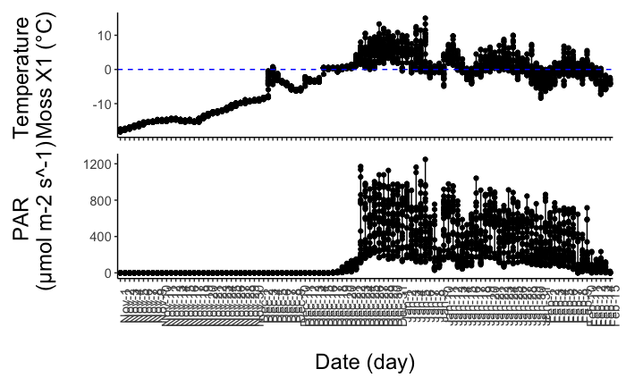

Sample X2 (moss)

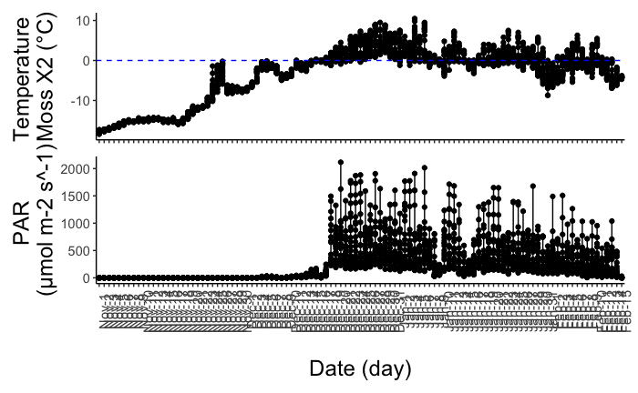

Sample X3 (Lichen)

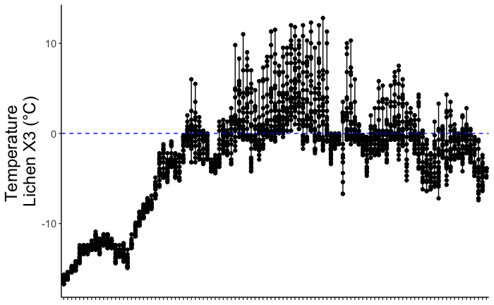

```r
(temp_plot_19_20_X3 <- summer_19_20 %>%
   ggplot(aes(Date_Combined, X3.Temp)) +
   geom_point()+  # Add points for the data
   geom_line()+  # add a line that joins the points
   geom_hline(yintercept = 0, color = "blue", linetype = "dashed") +
   labs(x = "\nDate (day)", y = "Temperature \nLichen X3 (°C)") +
   theme_graphs_env_cond()+
   theme(axis.text.x = element_blank(),
        axis.title.x = element_blank()))
```

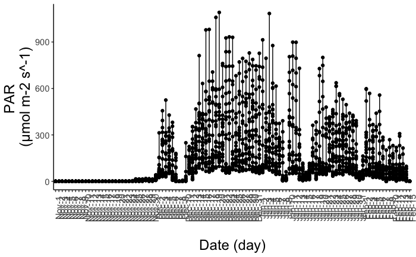

```r
(PAR_plot_19_20_X3 <-summer_19_20 %>%
    ggplot(aes(Date_Combined, X3.PAR)) +
   geom_point()+  # Add points for the data
   geom_line()+  # add a line that joins the points
   labs(x = "\nDate (day)", y = "PAR \n(µmol m-2 s^-1)") +
   theme_graphs_env_cond())
```

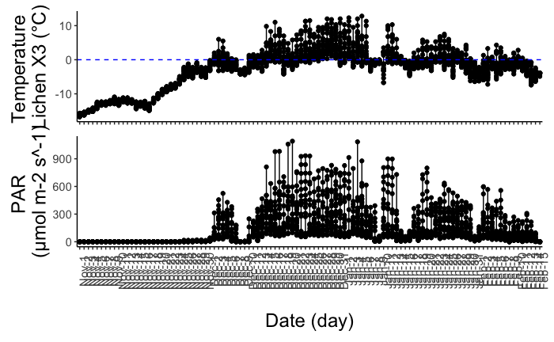

```r
(combined_plot_19_20_X3 <- (temp_plot_19_20_X3/PAR_plot_19_20_X3) & plot_layout(ncol = 1))
```

Sample X4 (Moss)

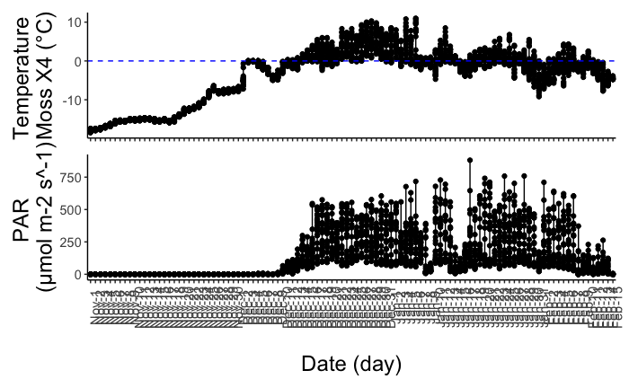

2. Summer 2020-2021

Sample X1 (Moss)

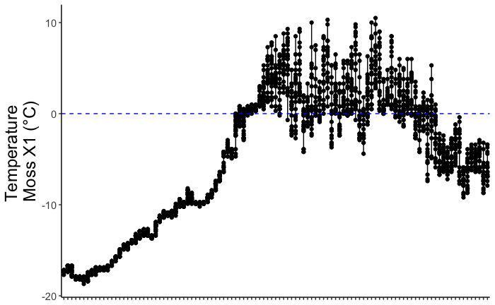

```r
(temp_plot_20_21_X1 <- summer_20_21 %>%
   ggplot(aes(Date_Combined, X1.Temp)) +
   geom_point()+  # Add points for the data
   geom_line()+  # Add a line that joins the points
   geom_hline(yintercept = 0, color = "blue", linetype = "dashed") +
   labs(x = "\nDate (day)", y = "Temperature \nMoss X1 (°C)") +
   theme_graphs_env_cond() +
    theme(axis.text.x = element_blank(),
        axis.title.x = element_blank()))  # Remove axis label and text for the graph
```

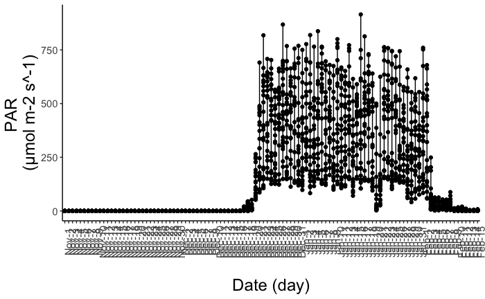

```r
(PAR_plot_20_21_X1 <-summer_20_21 %>%
    ggplot(aes(Date_Combined, X1.PAR)) +
   geom_point()+  # Add points for the data
   geom_line()+  # add a line that joins the points
   labs(x = "\nDate (day)", y = "PAR \n(µmol m-2 s^-1)") +
   theme_graphs_env_cond())
```

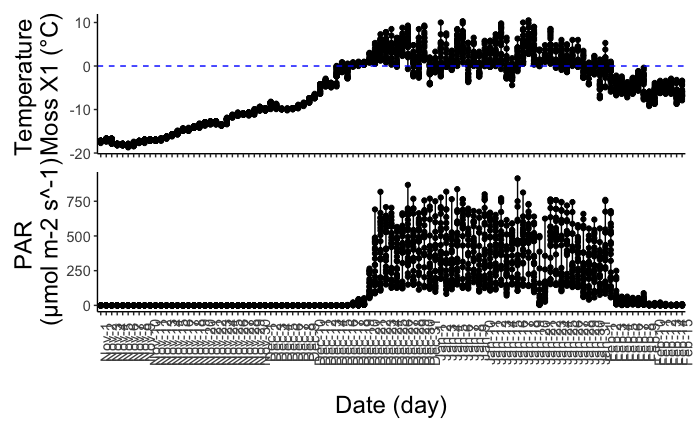

```r
(combined_plot_20_21_X1 <- (temp_plot_20_21_X1/PAR_plot_20_21_X1) & plot_layout(ncol = 1))
```

Sample X2 (Moss)

[figure not shown]

```r
(temp_plot_20_21_X2 <- summer_20_21 %>%
   ggplot(aes(Date_Combined, X2.Temp)) +
   geom_point()+  # Add points for the data
   geom_line()+  # Add a line that joins the points
   geom_hline(yintercept = 0, color = "blue", linetype = "dashed") +
   labs(x = "\nDate (day)", y = "Temperature \nMoss X1 (°C)") +
   theme_graphs_env_cond() +
    theme(axis.text.x = element_blank(),
        axis.title.x = element_blank()))  # Remove axis label and text for the graph
```

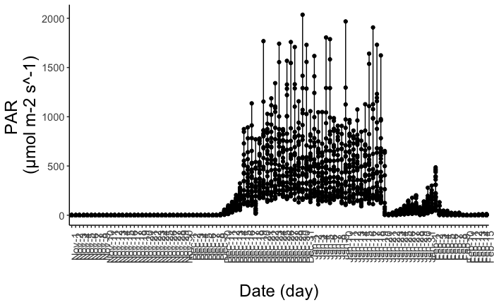

```r
(PAR_plot_20_21_X2 <-summer_20_21 %>%
    ggplot(aes(Date_Combined, X2.PAR)) +
   geom_point()+  # Add points for the data
   geom_line()+  # add a line that joins the points
   labs(x = "\nDate (day)", y = "PAR \n(µmol m-2 s^-1)") +
   theme_graphs_env_cond())
```

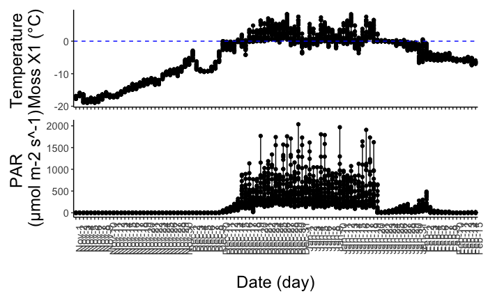

```r
(combined_plot_20_21_X2 <- (temp_plot_20_21_X2/PAR_plot_20_21_X2) & plot_layout(ncol = 1))
```

Saple X3 (Lichen)

[figure not shown]

```r
(temp_plot_20_21_X3 <- summer_20_21 %>%
   ggplot(aes(Date_Combined, X3.Temp)) +
   geom_point()+  # Add points for the data
   geom_line()+  # Add a line that joins the points
   geom_hline(yintercept = 0, color = "blue", linetype = "dashed") +
   labs(x = "\nDate (day)", y = "Temperature \nMoss X1 (°C)") +
   theme_graphs_env_cond() +
    theme(axis.text.x = element_blank(),
        axis.title.x = element_blank()))  # Remove axis label and text for the graph
```

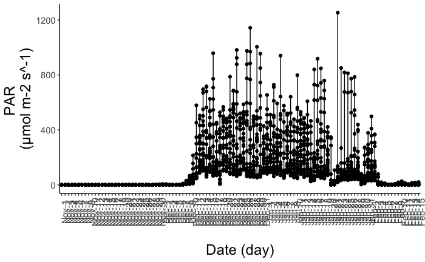

```r
(PAR_plot_20_21_X3 <-summer_20_21 %>%
    ggplot(aes(Date_Combined, X3.PAR)) +
   geom_point()+  # Add points for the data
   geom_line()+  # add a line that joins the points
   labs(x = "\nDate (day)", y = "PAR \n(µmol m-2 s^-1)") +
   theme_graphs_env_cond())
```

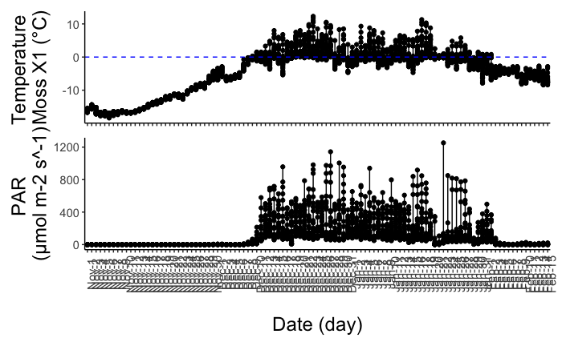

```r
(combined_plot_20_21_X3 <- (temp_plot_20_21_X3/PAR_plot_20_21_X3) & plot_layout(ncol = 1))
```